# Network Exploration in R

The [previous tutorial](https://dacss-cssmeths.github.io/Networks_intro/) we learned to prepare a network from a bipartite structure.

This is the link to that network from a GitHub repo:

```r
rm(list = ls())
GitLink='https://github.com/DACSS-CSSmeths/Networks_intro/raw/refs/heads/main/MyGraphs/css_bP.graphml'
```

The library **igraph** will be needed to open this file in R:

```r
library(igraph)
actors=read_graph(GitLink,format='graphml')
```

The **actors** object has the network data, let’s get some information:

```r
summary(actors)
```

```
## IGRAPH 295b0aa U-W- 11 14 --
## + attr: wonOscar (v/n), color (v/c), bipartite (v/n), id (v/c), weight
## | (e/n)
```

The above results mean:

- **UN**:Undirected
- **W**:weighted
- **11**:nodes
- **14**:edges

You also see the attributes for nodes (**v**ertices):

- (v/n) is a **n**umeric attribute for the nodes, here *wonOscar* and *bipartite*.
- (v/c) is a **c**haracter or string attribute for the nodes, here *id*.

Let’s see one of them:

```r
V(actors)$wonOscar
```

```
##  [1] 1 0 1 1 1 1 1 1 0 1 1
```

You also see the attributes for **e**dges:

- (e/n) is a **n**umeric attribute for the edges, here *weight*.

Let’s see that one too:

```r
E(actors)$weight
```

```
##  [1] 1 1 1 1 1 1 1 1 1 1 1 3 1 1
```

If you do not see the attribute **name** in the nodes (as it is the case here), it will help creating it so you see actual names instead of the *node number*:

```r
V(actors)$name=V(actors)$id
```

Let’s draw the network:

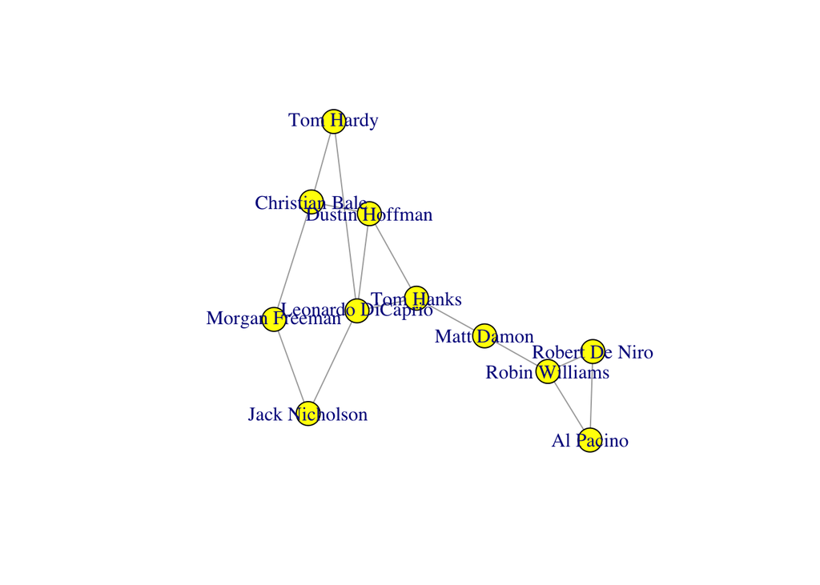

```r
set.seed(111) # use this to get same results as me

plot.igraph(actors)
```

Let’s use the attributes to change the look:

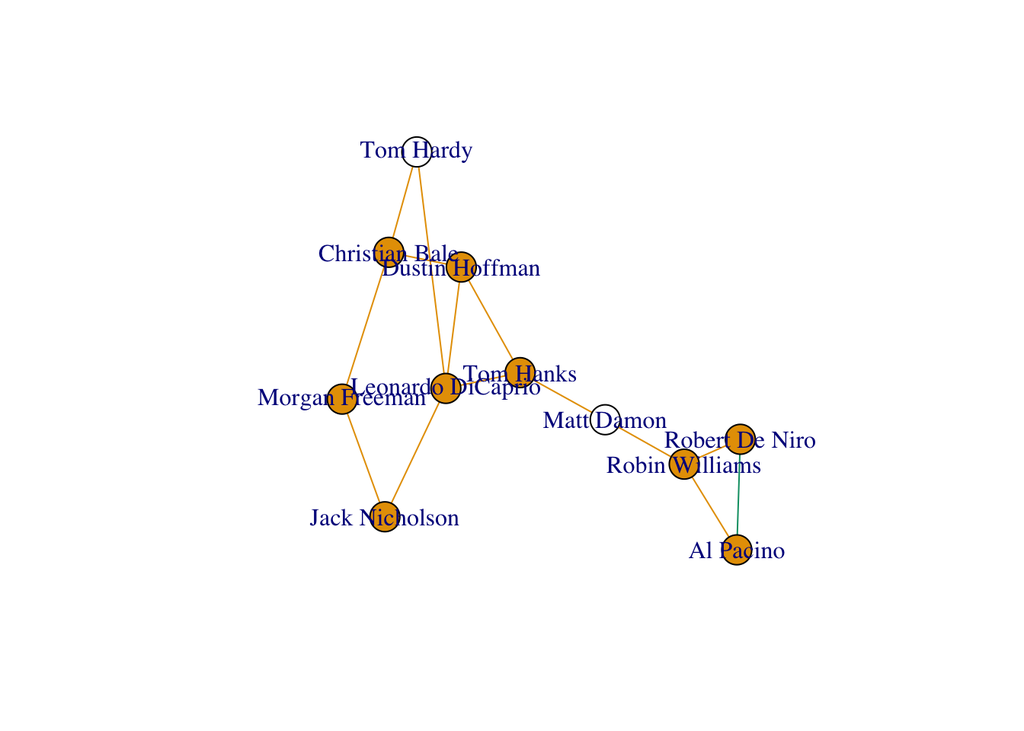

```r
set.seed(111) # use this to get same results as me

plot.igraph(actors,
            edge.color = E(actors)$weight,
            vertex.color=V(actors)$wonOscar)
```

Notice that the colors and weigth were chosen from the own R defaults.

## 1. Exploring the Network as a whole

There are several measures of a network:

- Connectedness: Can any two nodes reach each other (is there a path between them):

```r
is_connected(actors)
```

```
## [1] TRUE
```

Then, there is a way for one actor to meet another, because they have some other actors that can help introduce each other. If network is not connected, there will an actor that is not reachable by another. See the image below:

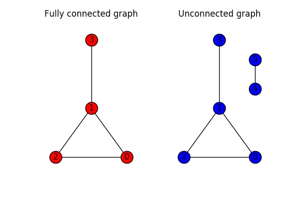

[image source](https://walkenho.github.io/graph-theory-and-networkX-part2/)

- Density: from 0 to 1. A value of 1 means we have a ‘complete’ network, that is, every node is connected by **one** link.

[figure not shown]

[image source](https://guides.co/g/the-network-effects-bible/121720)

```r
edge_density(actors)
```

```
## [1] 0.2545455
```

On average, any actor is connected to the 3 of the total (25% of 11 is 2.75). There are actors that are far from each other.

- Diameter (only computable for connected networks): A node can reach another following a path ( one or more egdes). The *geodesic* is the shorthest path between a pair nodes. Then, the diameter, is the maximum geodesic in a network.

```r
diameter(actors)
```

```
## [1] 6
```

Then, the pair of actors who are more distant among the group requires the help of 5 people (go through 6 edges) to reach each other.

We can actually find out the nodes whose geodesic represent the diameter.

```r
farthest_vertices(actors)
```

```
## $vertices
## + 2/11 vertices, named, from 295b0aa:
## [1] Al Pacino      Morgan Freeman
##
## $distance
## [1] 6
```

This is the geodesic between both nodes:

```r
get_diameter(actors)
```

```
## + 7/11 vertices, named, from 295b0aa:
## [1] Al Pacino      Robin Williams Matt Damon     Tom Hanks      Dustin Hoffman
## [6] Christian Bale Morgan Freeman
```

You can see that here:

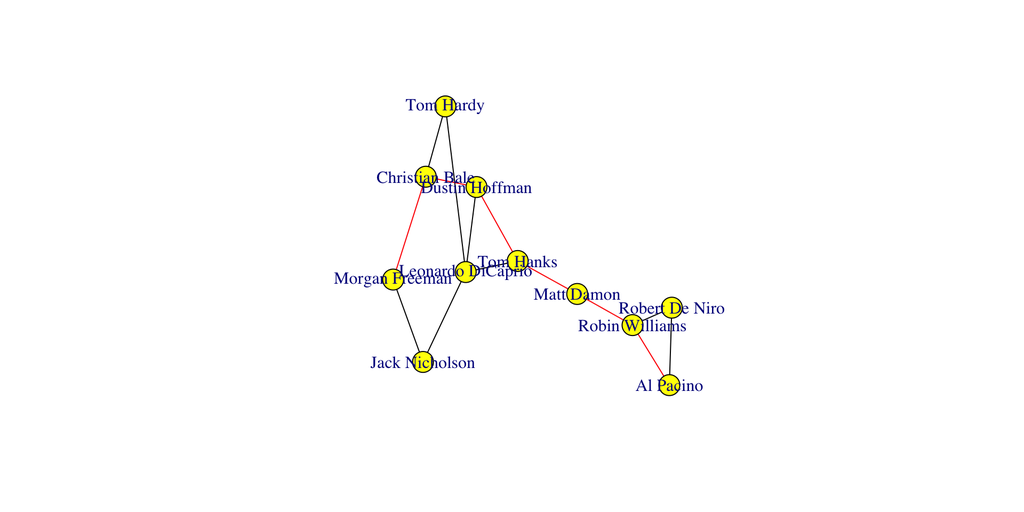

```r
set.seed(111)

# first the same color
diameterColor <- rep("black", ecount(actors))

# now change color if in the Diameter
diameterColor[E(actors, path=get_diameter(actors))] = "red"

plot.igraph(actors,
            edge.color = diameterColor,
            )
```

- Shortest path (average): it gets the average of every shortest path among the nodes in the network.

```r
mean_distance(actors)
```

```
## [1] 2.727273
```

Let’s turn our attention to the nodes and their roles in the network.

## 2. Exploration of network actors

Let’s focus on the relevance, or *centrality* of the vertices we have.

1. The **degree** of a vertex will tell you about the amount of connections of each node. A node with degree centrality of ONE (1) means that is connected to every other node.

```r
sort(degree(actors,normalized=T))
```

```
##         Tom Hardy         Al Pacino    Morgan Freeman    Robert De Niro
##               0.2               0.2               0.2               0.2
##        Matt Damon    Jack Nicholson    Robin Williams    Dustin Hoffman
##               0.2               0.2               0.3               0.3
##         Tom Hanks    Christian Bale Leonardo DiCaprio
##               0.3               0.3               0.4
```

DiCaprio is the most connected among them, but is not far from four other actors.

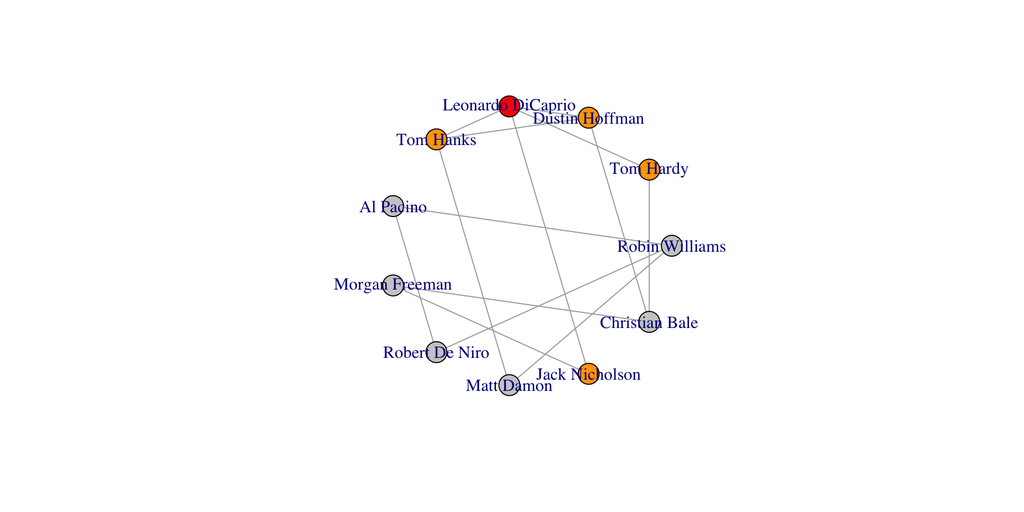

```r
set.seed(123)

TheV=c('Leonardo DiCaprio') # the one to highlight

# the neoghbors
neigh.nodes <- neighbors(actors, TheV)

# all vertices same color
vcol <- rep("grey80", vcount(actors))

# color for neighbors
vcol[neigh.nodes] <- "orange"

# color for TheV
vcol[V(actors)$name%in%TheV] <- "red"


plot(actors, vertex.color=vcol,layout=layout_in_circle)
```

2. The **closeness** of a vertex will tell you how close a vertex is to every other vertex. A vertex with high closeness can share information faster than the rest.

```r
sort(closeness(actors,normalized=T))
```

```
##         Al Pacino    Robert De Niro    Morgan Freeman    Robin Williams
##         0.2702703         0.2702703         0.3125000         0.3571429
##         Tom Hardy    Jack Nicholson    Christian Bale        Matt Damon
##         0.3703704         0.3703704         0.3846154         0.4347826
##    Dustin Hoffman Leonardo DiCaprio         Tom Hanks
##         0.4545455         0.4761905         0.5000000
```

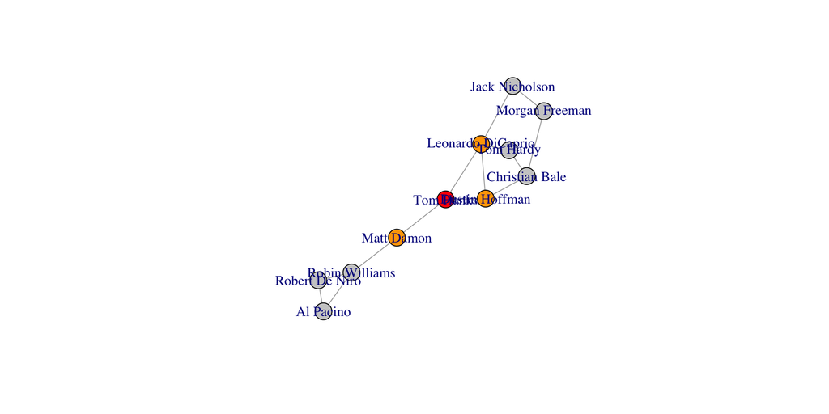

```r
set.seed(123)
TheV=c('Tom Hanks')
neigh.nodes <- neighbors(actors, TheV)
vcol <- rep("grey80", vcount(actors))
vcol[neigh.nodes] <- "orange"
vcol[V(actors)$name%in%TheV] <- "red"

plot(actors, vertex.color=vcol)
```

3. The **betweeness** of a vertex will tell you how critical a vertex is to connect vertices that are not connected directly.

```r
sort(betweenness(actors,normalized=T))
```

```
##         Al Pacino    Robert De Niro         Tom Hardy    Morgan Freeman
##        0.00000000        0.00000000        0.01111111        0.02222222
##    Jack Nicholson    Christian Bale    Dustin Hoffman Leonardo DiCaprio
##        0.07777778        0.11111111        0.17777778        0.33333333
##    Robin Williams        Matt Damon         Tom Hanks
##        0.37777778        0.46666667        0.53333333
```

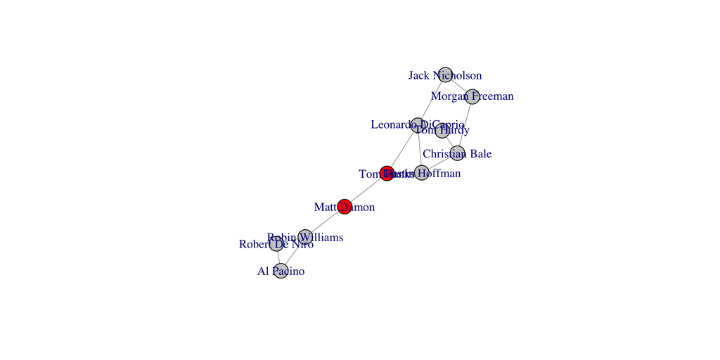

```r
set.seed(123)
TheV=c('Matt Damon', 'Tom Hanks')
neigh.nodes <- neighbors(actors, V(actors)[name%in%TheV])
# Set colors to plot the neighbors:
vcol <- rep("grey80", vcount(actors))
vcol[V(actors)$name%in%TheV] <- "red"


plot(actors, vertex.color=vcol,layout=layout.fruchterman.reingold)
```

Let me get all these centrality indexes into a dataframe:

```r
rounding=2
degr=round(degree(actors,normalized=T),rounding)
close=round(closeness(actors,normalized=T),rounding)
betw=round(betweenness(actors,normalized=T),rounding)

DFCentrality=as.data.frame(cbind(degr,close,betw),stringsAsFactors = F)
names(DFCentrality)=c('Degree','Closeness','Betweenness')
```

```r
DFCentrality$person=row.names(DFCentrality)
row.names(DFCentrality)=NULL
head(DFCentrality)
```

```
##   Degree Closeness Betweenness            person
## 1    0.3      0.36        0.38    Robin Williams
## 2    0.2      0.37        0.01         Tom Hardy
## 3    0.3      0.45        0.18    Dustin Hoffman
## 4    0.4      0.48        0.33 Leonardo DiCaprio
## 5    0.3      0.50        0.53         Tom Hanks
## 6    0.2      0.27        0.00         Al Pacino
```

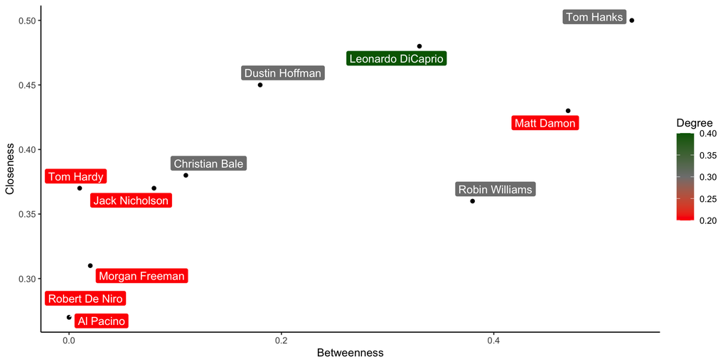

```r
library(ggplot2)
library(ggrepel)
ggplot(DFCentrality, aes(x=Betweenness, y=Closeness)) +
    theme_classic() + geom_point() +
    geom_label_repel(aes(label=person,fill=Degree),color='white') +
    scale_fill_gradient2(low = "red", mid='grey50',high ="darkgreen",
                           midpoint = 0.3)
```

You can clearly see who are the most important people in **this** network (biased due to my sampling by convenience).

Can this network be disconnected?

We know it is connected (*is.connected()* above gave es TRUE). But, we can compute the minimum number of nodes that must be removed to disconnect the network (create at least two components):

```r
vertex_connectivity(actors)
```

```
## [1] 1
```

So, the whole network can be splitted if one actor goes away.

Who is the node that can break the network?

```r
(TheCut=articulation_points(actors))
```

```
## + 3/11 vertices, named, from 295b0aa:
## [1] Tom Hanks      Matt Damon     Robin Williams
```

We just need to take ONE of those, and the network will split.

We can also find out the edge that is keeping the network from splitting:

```r
(TheBridge=bridges(actors))
```

```
## + 2/14 edges from 295b0aa (vertex names):
## [1] Tom Hanks     --Matt Damon Robin Williams--Matt Damon
```

We can highlight those *nodes*:

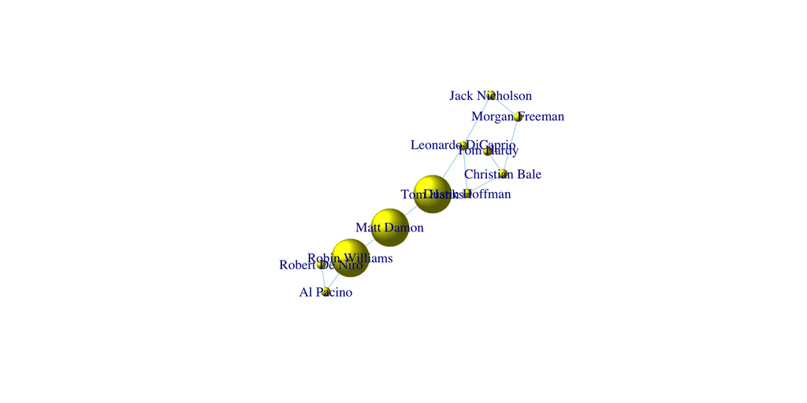

```r
allSizes=rep(10,vcount(actors))
allSizes[TheCut]=40

V(actors)$size=allSizes
set.seed(123)
plot.igraph(actors,layout = layout.fruchterman.reingold,
             vertex.color = 'yellow',
             edge.color='lightblue',vertex.shape='sphere')
```

We can highlight the *bridges* too:

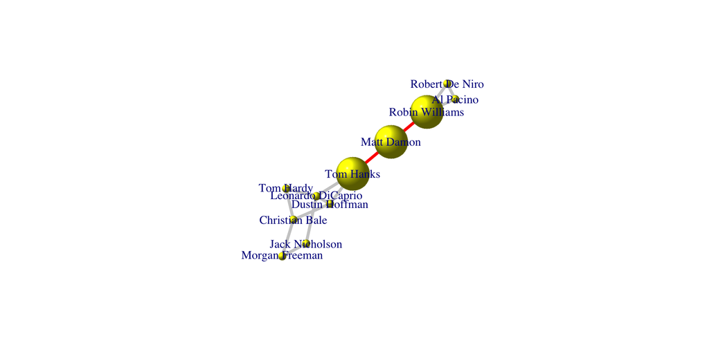

```r
E(actors)$color=ifelse(E(actors)%in%TheBridge,
                               'red','grey80')

plot.igraph(actors,layout = layout.fruchterman.reingold,
             vertex.color = 'yellow',edge.width=4,vertex.shape='sphere')
```

## And the Directed Graphs?

The centrality measures are applied differently to directed edges. In particular, we can use those measures to compute the INs and OUTs, that is, a measure based on what links are coming out from a node, or into a node.

Let me prepare a graph from two tables as we did in Python, now in R (igraph):

```r
library(rio)

edges=import('https://github.com/DACSS-CSSmeths/Networks_exploration/raw/refs/heads/main/data/presidents_2020_twitter.xlsx',which='edges')
nodes=import('https://github.com/DACSS-CSSmeths/Networks_exploration/raw/refs/heads/main/data/presidents_2020_twitter.xlsx',which='attributes')
```

The nodes are presidents in the Americas in the year 2020 (some basic attributes are available). The edges are show if a president follows another on Twitter.

Igraph can use both data frames to create a network like this:

```r
presis <- graph_from_data_frame(d=edges, vertices=nodes, directed=T)
#check
summary(presis)
```

```
## IGRAPH 4b0f53d DNW- 34 168 --
## + attr: name (v/c), country (v/c), region (v/c), sex (v/c), weight
## | (e/n)
```

Take a look:

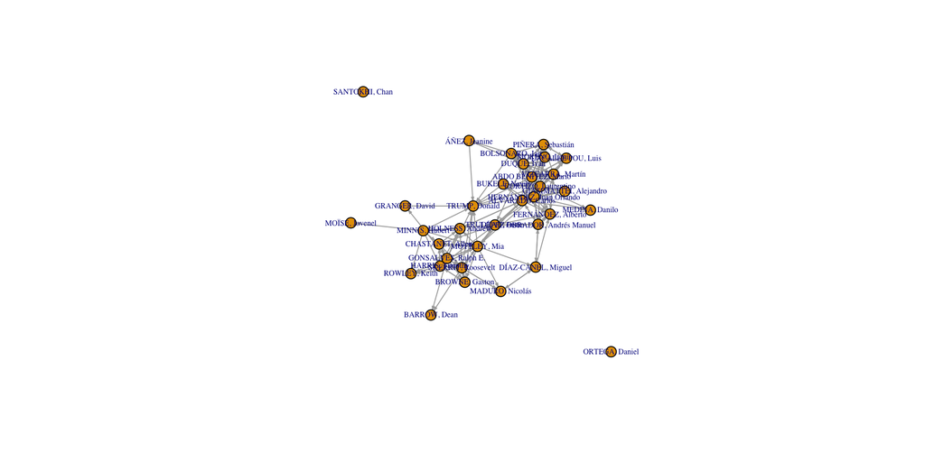

```r
set.seed(221)
plot(presis,vertex.size=8,edge.arrow.size=.2,layout=layout_with_fr,vertex.label.cex=0.5)
```

One detail you see above is that there are several nodes connected, and there is a pair of isolates. Then, this network is disconnected:

```r
is_connected(presis)
```

```
## [1] FALSE
```

Usually, when this happens, you have a *big* component and other smaller components, and even isolates (as it is the case here). We will keep the big component, generally known as the **giant component**. There are two ways of doing that here:

1. We get rid of isolates: This is NOT a general solution, and only works in cases like this, where the giant component is surrounded by isolates.

```r
isolates = which(degree(presis,mode='in') + degree(presis,mode='out')==0 )
presis_noIsolates = delete_vertices(presis, isolates)
## result
summary(presis_noIsolates)
```

```
## IGRAPH e5dfcab DNW- 32 168 --
## + attr: name (v/c), country (v/c), region (v/c), sex (v/c), weight
## | (e/n)
```

The new network looks as expected:

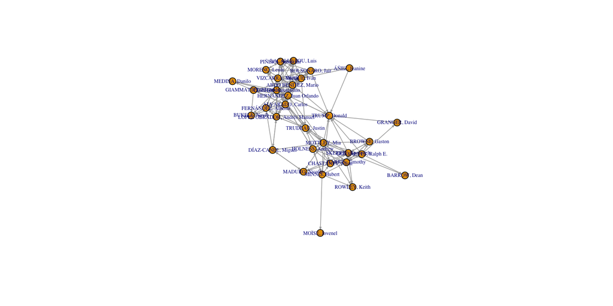

```r
set.seed(221)
plot(presis_noIsolates,vertex.size=8,edge.arrow.size=.2,layout=layout_with_fr,vertex.label.cex=0.5)
```

2. Keep the giant component: This is a general solution. To make things easy, please install **CINNA**. Use it like this:

```r
presis_BIG=CINNA::giant_component_extract(presis)
# result
summary(presis_BIG)
```

```
##      Length Class  Mode
## [1,]  32    igraph list
## [2,] 336    -none- character
```

Notice that *presis_BIG* is not a network, It is a list, the first element is the network, the second the edgelist of the network. Let’s check the network to confirm the two isolates are not included.

```r
summary(presis_BIG[[1]])
```

```
## IGRAPH df65d91 DNW- 32 168 --
## + attr: name (v/c), country (v/c), region (v/c), sex (v/c), weight
## | (e/n)
```

Redrawing, this time labelling with country of the president:

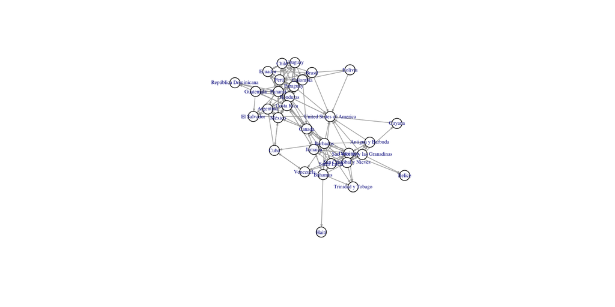

```r
presis_giant=presis_BIG[[1]]
set.seed(221)
plot(presis_giant,vertex.size=12,edge.arrow.size=.2,layout=layout_with_fr,
     vertex.color='white',
     vertex.label=V(presis_giant)$country,
     vertex.label.cex=0.5)
```

Let’s use this graph to compute the centrality measures:

```r
# notice In and OUT
degreeIn=degree(presis_giant,mode='in',normalized = T)
degreeOut=degree(presis_giant,mode='out',normalized = T)
closeIn=closeness(presis_giant,mode='in',normalized = T)
closeOut=closeness(presis_giant,mode='out',normalized = T)
# no In nor OUT, just 'directed'
betwD=betweenness(presis_giant,directed=T,normalized = T)

# the data frame
presisCentrality=as.data.frame(cbind(degreeIn,degreeOut,closeIn,closeOut,betwD))
presisCentrality
```

```
##                                degreeIn  degreeOut   closeIn  closeOut
## VIZCARRA, Martín             0.19354839 0.25806452 0.4705882 0.3780488
## TRUMP, Donald                0.38709677 0.00000000 0.5744681       NaN
## TRUDEAU, Justin              0.35483871 0.03225806 0.6315789 0.3039216
## SKERRIT, Roosevelt           0.16129032 0.29032258 0.3380282 0.4305556
## ROWLEY, Keith                0.12903226 0.00000000 0.3424658       NaN
## PIÑERA, Sebastián            0.29032258 0.09677419 0.4800000 0.3163265
## MOTTLEY, Mia                 0.22580645 0.35483871 0.4528302 0.5535714
## MORENO, Lenín                0.19354839 0.09677419 0.4444444 0.4025974
## MOÏSE, Jovenel               0.03225806 0.00000000 0.2475248       NaN
## MINNIS, Hubert               0.03225806 0.25806452 0.3157895 0.4246575
## MEDINA, Danilo               0.09677419 0.00000000 0.3968254       NaN
## MADURO, Nicolás              0.12903226 0.03225806 0.3809524 0.2460317
## LÓPEZ OBRADOR, Andrés Manuel 0.25806452 0.19354839 0.5454545 0.4305556
## LACALLE POU, Luis            0.19354839 0.09677419 0.4444444 0.3333333
## HOLNESS, Andrew              0.22580645 0.06451613 0.4528302 0.4305556
## HERNÁNDEZ, Juan Orlando      0.16129032 0.48387097 0.4528302 0.5740741
## HARRIS, Timothy              0.19354839 0.25806452 0.3478261 0.4305556
## GRANGER, David               0.03225806 0.03225806 0.2136752 1.0000000
## GONSALVES, Ralph E.          0.03225806 0.32258065 0.2608696 0.4366197
## GIAMMATTEI, Alejandro        0.09677419 0.16129032 0.3934426 0.4133333
## FERNÁNDEZ, Alberto           0.19354839 0.16129032 0.4705882 0.3522727
## DUQUE, Iván                  0.32258065 0.19354839 0.4897959 0.3604651
## DÍAZ-CANEL, Miguel           0.09677419 0.09677419 0.4285714 0.3229167
## CORTIZO, Laurentino          0.22580645 0.48387097 0.4897959 0.4920635
## CHASTANET, Allen             0.12903226 0.16129032 0.3380282 0.4078947
## BUKELE, Nayib                0.12903226 0.03225806 0.4237288 1.0000000
## BROWNE, Gaston               0.12903226 0.09677419 0.3333333 0.3195876
## BOLSONARO, Jair              0.16129032 0.22580645 0.3870968 0.3522727
## BARROW, Dean                 0.06451613 0.00000000 0.2631579       NaN
## ÁÑEZ, Jeanine                0.03225806 0.06451613 0.2857143 0.2743363
## ALVARADO, Carlos             0.25806452 0.51612903 0.5581395 0.5961538
## ABDO BENITEZ, Mario          0.25806452 0.35483871 0.4897959 0.4626866
##                                     betwD
## VIZCARRA, Martín             0.0165809012
## TRUMP, Donald                0.0000000000
## TRUDEAU, Justin              0.0145413040
## SKERRIT, Roosevelt           0.0405704898
## ROWLEY, Keith                0.0000000000
## PIÑERA, Sebastián            0.0029569892
```

[output cut: 11 more lines]

```
## GRANGER, David               0.0000000000
## GONSALVES, Ralph E.          0.0274551971
## GIAMMATTEI, Alejandro        0.0002688172
## FERNÁNDEZ, Alberto           0.0185151050
## DUQUE, Iván                  0.0534203789
## DÍAZ-CANEL, Miguel           0.0424372760
## CORTIZO, Laurentino          0.0722734255
## CHASTANET, Allen             0.0015143369
## BUKELE, Nayib                0.0016487455
## BROWNE, Gaston               0.0002688172
## BOLSONARO, Jair              0.0266487455
## BARROW, Dean                 0.0000000000
## ÁÑEZ, Jeanine                0.0000000000
## ALVARADO, Carlos             0.2819781533
## ABDO BENITEZ, Mario          0.0852201741
```

You can also compute the diameter:

```r
get_diameter(presis_giant,directed = TRUE)
```

```
## + 8/32 vertices, named, from df65d91:
## [1] MADURO, Nicolás              DÍAZ-CANEL, Miguel
## [3] LÓPEZ OBRADOR, Andrés Manuel ALVARADO, Carlos
## [5] MOTTLEY, Mia                 HARRIS, Timothy
## [7] GONSALVES, Ralph E.          GRANGER, David
```

Even though you have the giant component, you can still break the network:

```r
(TheBridge=bridges(presis_giant))
```

```
## + 1/168 edge from df65d91 (vertex names):
## [1] MINNIS, Hubert->MOÏSE, Jovenel
```

```r
(TheCut=articulation_points(presis_giant))
```

```
## + 1/32 vertex, named, from df65d91:
## [1] MINNIS, Hubert
```

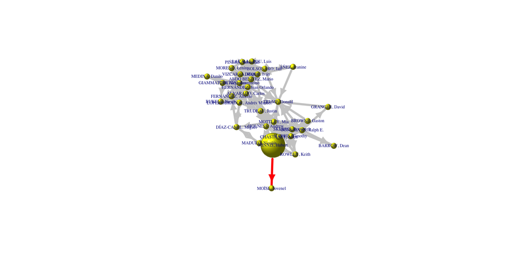

```r
set.seed(221)
allSizes=rep(10,vcount(presis_giant))
allSizes[TheCut]=40

V(presis_giant)$size=allSizes

E(presis_giant)$color=ifelse(E(presis_giant)%in%TheBridge,
                               'red','grey80')

plot.igraph(presis_giant,layout = layout.fruchterman.reingold,,
     vertex.label.cex=0.5,
             vertex.color = 'yellow',edge.width=4,vertex.shape='sphere')
```

## LINK ANALYSIS

This analysis is only useful in directed graphs. These measures were born to identify important web pages, based on the visits received by the current page, the previous pages that caused the visit to the current one, and the visit to pages that would come after visiting the current one. In synthesis, high values reveal important nodes, meaning that there should be some good content in those nodes, because in also comes from other important nodes, and will guide you to visit other relevent nodes. We have:

- HUBS and AUTHORITIES: These two work together. If you send links you are a hub, if you receive link you are an authority. HUBS become relevant if they send link to important AUTHORITIES. AUTHORITIES become relevant if they receive links from important HUBS. Of course, in a NON directed graph, those measures are no different.
- PAGE RANK: Page rank simplifies the HUBS and AUTHORITIES in one measure. Then, the higher the values the most important the node in terms of receiving and sending.

Let’s compute those values:

```r
Lk_hub=hub_score(presis_giant)$vector
Lk_auth=authority_score(presis_giant)$vector
Lk_page=page_rank(presis_giant)$vector
presis_LINK=as.data.frame(cbind(Lk_hub,Lk_auth,Lk_page))
presis_LINK
```

```
##                                    Lk_hub    Lk_auth     Lk_page
## VIZCARRA, Martín             5.641975e-01 0.69466814 0.036759206
## TRUMP, Donald                2.576022e-16 0.88148669 0.061367944
## TRUDEAU, Justin              7.397102e-02 0.99538806 0.053276867
## SKERRIT, Roosevelt           3.550766e-01 0.23192231 0.018539369
## ROWLEY, Keith                9.660084e-17 0.23923138 0.014886056
## PIÑERA, Sebastián            2.226767e-01 0.99049971 0.056944323
## MOTTLEY, Mia                 4.046983e-01 0.61176013 0.021072531
## MORENO, Lenín                2.053041e-01 0.77592873 0.038576252
## MOÏSE, Jovenel               2.415021e-17 0.05835404 0.009389516
## MINNIS, Hubert               3.315701e-01 0.01095903 0.016509968
## MEDINA, Danilo               6.440056e-17 0.52459058 0.015118429
## MADURO, Nicolás              1.131112e-02 0.21158332 0.023684971
## LÓPEZ OBRADOR, Andrés Manuel 3.258321e-01 0.85381260 0.087510170
## LACALLE POU, Luis            2.488951e-01 0.79432319 0.038998293
## HOLNESS, Andrew              6.226964e-02 0.50712423 0.020881497
## HERNÁNDEZ, Juan Orlando      9.992439e-01 0.58960786 0.032106445
## HARRIS, Timothy              2.679777e-01 0.30560515 0.019927226
## GRANGER, David               7.636860e-02 0.05146682 0.008464302
## GONSALVES, Ralph E.          2.924366e-01 0.04716222 0.009752599
## GIAMMATTEI, Alejandro        2.970850e-01 0.52459058 0.015118429
## FERNÁNDEZ, Alberto           3.367133e-01 0.66614170 0.044231583
## DUQUE, Iván                  4.234812e-01 1.00000000 0.060827123
## DÍAZ-CANEL, Miguel           1.500137e-01 0.13055897 0.041793163
## CORTIZO, Laurentino          9.815016e-01 0.67143890 0.050667459
## CHASTANET, Allen             2.297417e-01 0.22820718 0.013964086
## BUKELE, Nayib                7.636860e-02 0.46027468 0.023388566
## BROWNE, Gaston               1.229379e-01 0.23234416 0.013960842
## BOLSONARO, Jair              4.596794e-01 0.65367031 0.028688668
## BARROW, Dean                 4.830042e-17 0.11395784 0.010215243
## ÁÑEZ, Jeanine                1.630047e-01 0.08090040 0.011118956
## ALVARADO, Carlos             1.000000e+00 0.70779002 0.052566140
## ABDO BENITEZ, Mario          7.457577e-01 0.88237861 0.049693780
```

Let’s see a plot of Hubs, Authorities, and Page Rank:

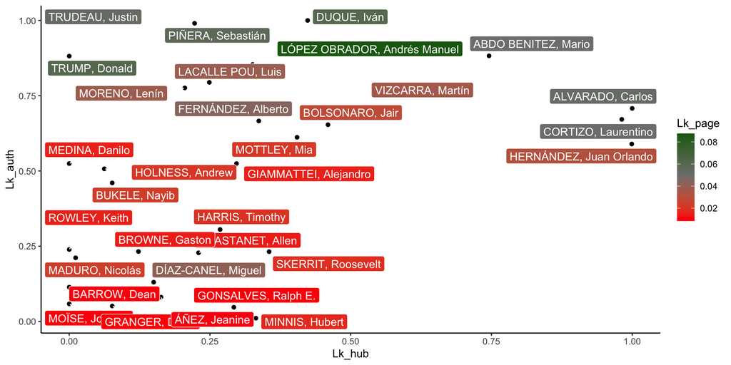

```r
presis_LINK$person=row.names(presis_LINK)

ggplot(presis_LINK, aes(x=Lk_hub, y=Lk_auth)) +
    theme_classic() + geom_point() +
    geom_label_repel(aes(label=person,fill=Lk_page),color='white') +
    scale_fill_gradient2(low = "red", mid='grey50',high ="darkgreen",
                           midpoint = 0.05)
```

We can export our presidents graph (the original) this way:

```r
write_graph(
  presis,
  'presis.graphml',
  format ="graphml")
```

It is time go to CANVAS to see the Homework instructions!